# Using variable importance for individual samples

Yi Chen

2024-08-09

# 1 Introduction

[Link to RCE paper](https://link.springer.com/article/10.1007/s10994-013-5337-8)

This document examines the usage of the individual sample variable importance scores instead of the one produced by the RCE software. One of the main outputs is the proportion of out-of-bag samples that change cluster assignment after permutation as a metric of unsupervised feature importance. However, they do not report this information ($n x d$ matrix). Rather, they first use the pairwise distance matrix to calculate a final clustering and report aggregated variable importance per cluster ($n x k$ matrix) rather than for individual samples.

I suspect that skipping this last clustering step and considering a mean variable importance over samples (i.e., the mean or sum) may be a more stable metric.

# 2 Parkinsons data set

```r
run_RCE2 = function(data, nclusters, nbiter, vfun=message) {
    data = as.data.frame(data)
    k <- ncol(data) # Total number of features
    n <- nrow(data) # Number of instances
    p_bag <- round(sqrt(k)) # number of features for each bag

    # For normalization
    # Yi - I removed the caret dependency by manually range scaling the data
    data <- as.data.frame(apply(data, 2, function(x) {
                        (x - min(x, na.rm=T)) / (max(x, na.rm=T) - min(x, na.rm=T))
    }))

    # Performs consensus clustering for feature selection
    consensus_result <- consensus(data, nbiter, n, nclusters, k + 1, p_bag, vfun=vfun)
    M <- consensus_result$M
    imp <- consensus_result$imp

    # Calculate the similarity matrix from the co-association matrix
    SK <- M %*% t(M)
    # Convert to dissimilarity matrix
    Diss <- 1 - SK / nbiter
    diag(Diss) <- 0
    # Perform hierarchical clustering
    Z <- hclust(as.dist(Diss), method = "average")
    K_before <- cutree(Z, k = nclusters)

    # Normalize feature importance scores
    for (i in 1:n) {
        for (j in 1:(k)) {
            imp[i, j] <- imp[i, j] / nbiter
        }
    }

    # Aggregate feature importance scores for each cluster
    imp_var <- matrix(0, nclusters, k)
    for (i in 1:n) {
        for (j in 1:(k)) {
            imp_var[K_before[i], j] <- imp_var[K_before[i], j] + imp[i, j]
        }
    }

    # Return the selected features
    selected_features_result <- scree_test(imp_var, nclusters, k)
    selected_features <- selected_features_result$selected_features
    sf_unique <- selected_features_result$sf_unique

    vimp = data.frame(variable = colnames(data), importance = apply(imp, 2, mean))
    vimp = vimp[order(vimp$importance, decreasing=T), ]
    rownames(vimp) = NULL

    return(list(imp_var = imp_var,
                selected_features = sf_unique,
                k_before = K_before,
                imp_samp = imp,
                imp = apply(imp, 2, mean)
                ))
}
```

```r
data <- read.table("../example_data/Bases/parkinson.txt", header=F, sep = "\t")
k = ncol(data)
V <- data[, k] # True clustering
true_nclusters <- max(V) # Number of clusters
data <- data[, 1:(k - 1)]

parkinson_ind_vimp = cache_rds({
    mclapply(1:200, function(j) run_RCE2(data, nclusters=2, nbiter=200, vfun=ic)$imp, mc.cores=4)
}, rerun=F, clean=T)
```

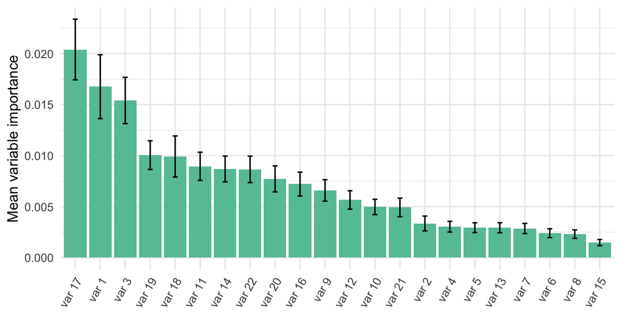

```r
tmp = do.call('rbind', parkinson_ind_vimp)
tmp = data.frame(
    mean=apply(tmp, 2, mean),
    sd=apply(tmp, 2, sd),
    varnum = paste("var", 1:ncol(tmp))
)
tmp$varnum = factor(tmp$varnum, levels=tmp$varnum[order(tmp$mean, decreasing=T)])
ggplot(tmp) +
    geom_bar(aes(x=varnum, y=mean, fill="1"), stat="identity") +
    geom_errorbar(aes(x=varnum, ymin=mean-sd, ymax=mean+sd), width=0.2) +
    xlab('') +
    ylab('Mean variable importance') +
    scale_fill_brewer(palette="Set2", guide="none") +
    theme_minimal() +
    theme(axis.text.x = element_text(angle = 60, vjust = 1, hjust=1))
```

```r
spearmandist = function(x, y) {
    (1 - cor(x, y, method="spearman")) / 2
}
```

```r
tmp = do.call('cbind', parkinson_ind_vimp)
y = apply(tmp, 1, mean)
cor(tmp, y)
```

[output not shown]

# 3 Breast Tissue

```r
data <- read.table("../example_data/Bases/Breast_Tissu.txt", header=F, sep = "\t")
k = ncol(data)
V <- data[, k] # True clustering
true_nclusters <- max(V) # Number of clusters
data <- data[, 1:(k - 1)]

bt_ind_vimp = cache_rds({
    mclapply(1:200, function(j) run_RCE2(data, nclusters=2, nbiter=200, vfun=ic)$imp, mc.cores=4)
}, rerun=F, clean=T)
```

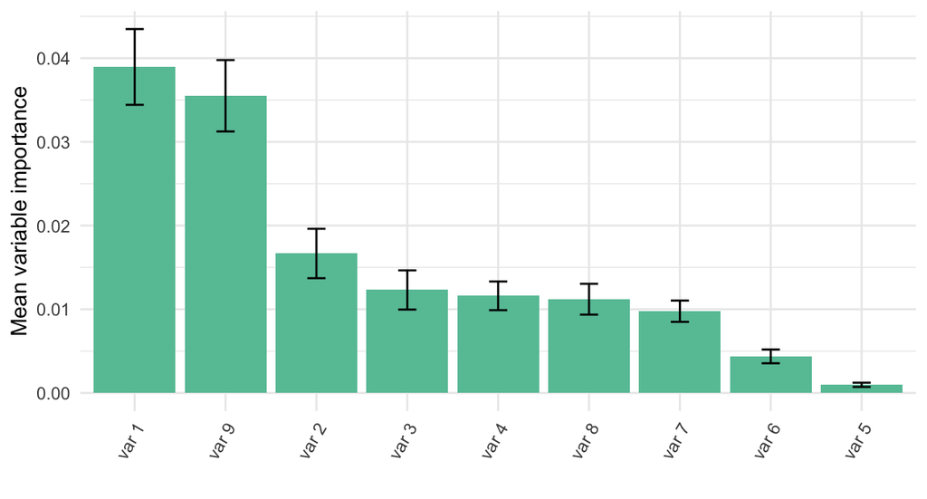

```r
tmp = do.call('rbind', bt_ind_vimp)
tmp = data.frame(
    mean=apply(tmp, 2, mean),
    sd=apply(tmp, 2, sd),
    varnum = paste("var", 1:ncol(tmp))
)
tmp$varnum = factor(tmp$varnum, levels=tmp$varnum[order(tmp$mean, decreasing=T)])
ggplot(tmp) +
    geom_bar(aes(x=varnum, y=mean, fill="1"), stat="identity") +
    geom_errorbar(aes(x=varnum, ymin=mean-sd, ymax=mean+sd), width=0.2) +
    xlab('') +
    ylab('Mean variable importance') +
    scale_fill_brewer(palette="Set2", guide="none") +
    theme_minimal() +
    theme(axis.text.x = element_text(angle = 60, vjust = 1, hjust=1))
```

# 4 Conclusions

- The variable importance values seem far more stable than when aggregating over a cluster label
- The ordering of the variable importance in the breast tissue data set is different than from the original implementation. Previously, var 2 ranked highest, followed by var 1 and var 9. Now, the variable 2 importance is much lower than the other two.